# Lecture note: 2017 Advanced biological statics

[Youngjun Na (ruminoreticulum@gmail.com)](https://github.com/YoungjunNa)

9/29/2017

# 0. 참고할 문서

1. [R 기본](http://github.com/rstudio/cheatsheets/raw/master/base-r.pdf)
2. [데이터 가공](https://github.com/rstudio/cheatsheets/raw/master/data-transformation.pdf)
3. [데이터 시각화](https://github.com/rstudio/cheatsheets/raw/master/data-visualization-2.1.pdf)
4. [연동형 문서 작성](https://www.rstudio.com/wp-content/uploads/2015/03/rmarkdown-reference.pdf)

# 1. 일단 따라해봅시다

- **1. R 기본 문서를 참고해 주세요**

## 1.1. 정의하기

```r
a<-10 #a는 10입니다.
b<-5 #b는 5입니다.
c<-"animal" #c는 animal입니다.
```

- 주의: 변수 이름은 문자로 시작해야합니다.

## 1.2. 출력하기

```r
a
```

```
## [1] 10
```

```r
b
```

```
## [1] 5
```

```r
c
```

```
## [1] "animal"
```

## 1.3. 사칙연산

```r
a+b #더하기
```

```
## [1] 15
```

```r
a-b #빼기
```

```
## [1] 5
```

```r
a/b #나누기
```

```
## [1] 2
```

```r
a*b #곱하기
```

```
## [1] 50
```

```r
a^2 #제곱
```

```
## [1] 100
```

```r
sqrt(a^2) #루트
```

```
## [1] 10
```

## 1.4. 논리

```r
a==b #a는 b와 같다.
```

```
## [1] FALSE
```

```r
a!=b #a는 b와 같지 않다.
```

```
## [1] TRUE
```

```r
a>b #a는 b보다 크다.
```

```
## [1] TRUE
```

```r
a<b #a는 b보다 작다.
```

```
## [1] FALSE
```

```r
a>=b #a는 b보다 크거나 같다.
```

```
## [1] TRUE
```

```r
a<=b #a는 b보다 작거나 같다.
```

```
## [1] FALSE
```

## 1.5. 데이터프레임

```r
a<-1:10

a
```

```
##  [1]  1  2  3  4  5  6  7  8  9 10
```

```r
b<-c(1,2,3,4,5,10)

b
```

```
## [1]  1  2  3  4  5 10
```

```r
c<-c("Konkuk","University")

c
```

```
## [1] "Konkuk"     "University"
```

- c는 ’합치다’라는 뜻의 ’combine’의 약자입니다.

```r
example<-data.frame(name=c("철수","영희","건이"), sex=c("Male","Female","Male"),age=c(29,40,33), height=c(175,163,168))

example
```

| name | sex | age | height |
| --- | --- | --- | --- |
| 철수 | Male | 29 | 175 |
| 영희 | Female | 40 | 163 |
| 건이 | Male | 33 | 168 |

```r
x<-example$height #example 데이터 중 height 데이터만 추출
x
```

```
## [1] 175 163 168
```

```r
example[2,3]
```

```
## [1] 40
```

```r
example[3,3]
```

```
## [1] 33
```

```r
example[,3]
```

```
## [1] 29 40 33
```

```r
example[1,]
```

| name | sex | age | height |
| --- | --- | --- | --- |
| 철수 | Male | 29 | 175 |

```r
example[-1,]
```

| name | sex | age | height |
| --- | --- | --- | --- |
| 영희 | Female | 40 | 163 |
| 건이 | Male | 33 | 168 |

```r
example[c(2,3),]
```

| name | sex | age | height |
| --- | --- | --- | --- |
| 영희 | Female | 40 | 163 |
| 건이 | Male | 33 | 168 |

## 1.6. 기본 통계

```r
sum(x) #합계
```

```
## [1] 506
```

```r
mean(x) #평균
```

```
## [1] 168.6667
```

```r
median(x) #중간값
```

```
## [1] 168
```

```r
var(x) #분산
```

```
## [1] 36.33333
```

```r
sd(x) #표준편차
```

```
## [1] 6.027714
```

```r
max(x) #최대값
```

```
## [1] 175
```

```r
min(x) #최소값
```

```
## [1] 163
```

```r
range(x) #범위
```

```
## [1] 163 175
```

# 2. 기초 R 문법

## 2.1. Working directory 확인

```r
getwd()
```

```
## [1] "/Users/Youngjun/Google Drive/Lecture/2017/건국대학교/생물통계학특론(농축대학원)"
```

## 2.2. Working directory 설정

```r
setwd("/Users/Youngjun/Google Drive/wd")
```

- R studio > Tools > Global option > Default working directory 에서 바꿀수도 있습니다.

## 2.3. Working directory 안에 있는 파일 확인

```r
dir()
```

```
##  [1] "2017 생물통계학특론 설문.gform"
##  [2] "2017 생물통계학특론 설문(응답).gsheet"
##  [3] "2017 생물통계학특론 INTRO.gslides"
##  [4] "2017 lecture note.Rmd"
##  [5] "2017_Advanced_biological_statics_intro.pdf"
##  [6] "2017_lecture_note.html"
##  [7] "2017_lecture_note.md"
##  [8] "2017_lecture_note.Rmd"
##  [9] "출석부.xlsx"
## [10] "행정"
## [11] "example_df.xlsx"
## [12] "lecture note.R"
## [13] "syllabus.pdf"
```

## 2.4. 패키지 인스톨

```r
install.packages("dplyr")
install.packages("ggplot2")
install.packages("readxl")
```

## 2.5. 패키지 업데이트

```r
update.packages(ask=FALSE)
```

## 2.6. 패키지 로딩

```r
library(dplyr)
library(ggplot2)
```

## 2.7. 파일 읽기

```r
read.csv("dataframe.csv")
readxl::read_excel("dataframe.xlsx")
```

## 2.8. 파일 쓰기

```r
write.csv(example, "test.txt", row.names=FALSE)
```

# 3. 데이터 가공: dplyr 패키지

- **2. 데이터 가공 문서를 참고해 주세요**

## 3.0. 패키지 로딩 및 데이터 읽기

```r
library(dplyr)
readxl::read_excel("example_df.xlsx")
```

| birthYMD | butcheryYmd | month | animalNo | gradeNm | qgrade | wgrade | weight | windex | Name |
| --- | --- | --- | --- | --- | --- | --- | --- | --- | --- |
| 2014-02-23 | 2016-04-29 | 26.16986 | 2306143937 | 1++A | 1++ | A | 449 | 67 | Na |
| 2014-02-16 | 2016-04-29 | 26.40000 | 2307366853 | 1++A | 1++ | A | 434 | 68 | Na |
| 2014-01-26 | 2016-04-29 | 27.09041 | 2307361832 | 1+A | 1+ | A | 401 | 69 | Na |
| 2014-01-16 | 2016-04-29 | 27.41918 | 2089857096 | 1C | 1 | C | 590 | 59 | Na |
| 2014-04-27 | 2016-04-29 | 24.09863 | 2308347605 | 1A | 1 | A | 454 | 69 | Na |
| 2014-05-11 | 2016-04-29 | 23.63836 | 2308532906 | 1+B | 1+ | B | 439 | 64 | Na |
| 2014-04-20 | 2016-04-29 | 24.32877 | 2308320115 | 1+C | 1+ | C | 494 | 62 | Na |
| 2014-04-01 | 2016-04-29 | 24.95342 | 2090790866 | 2B | 2 | B | 317 | 67 | Na |
| 2014-03-19 | 2016-04-29 | 25.38082 | 2307979754 | 1+B | 1+ | B | 479 | 65 | Na |
| 2013-02-26 | 2015-04-06 | 25.28219 | 2083187890 | 3A | 3 | A | 205 | 69 | Na |

[output cut: 139 more lines]

```r
df<-readxl::read_excel("example_df.xlsx")
```

## 3.1. 필요한 데이터만 추출하기: filter

```r
filter(df, Name=="Kim")
```

| birthYMD | butcheryYmd | month | animalNo | gradeNm | qgrade | wgrade | weight | windex | Name |
| --- | --- | --- | --- | --- | --- | --- | --- | --- | --- |
| 2013-09-17 | 2016-04-28 | 31.36438 | 2087042586 | 1+C | 1+ | C | 458 | 59 | Kim |
| 2013-09-03 | 2016-04-28 | 31.82466 | 2306539562 | 1++A | 1++ | A | 394 | 68 | Kim |
| 2013-07-18 | 2016-04-28 | 33.36986 | 2306538682 | 1+A | 1+ | A | 481 | 71 | Kim |
| 2013-08-16 | 2016-04-28 | 32.41644 | 2086797156 | 1+B | 1+ | B | 444 | 65 | Kim |
| 2013-09-09 | 2016-04-28 | 31.62740 | 2087040566 | 1B | 1 | B | 466 | 66 | Kim |
| 2014-09-16 | 2016-06-13 | 20.90959 | 2094509816 | 2C | 2 | C | 436 | 63 | Kim |
| 2014-03-06 | 2016-10-10 | 31.20000 | 2087407038 | 2A | 2 | A | 393 | 68 | Kim |
| 2014-03-22 | 2016-10-10 | 30.67397 | 2090235097 | 1++B | 1++ | B | 419 | 65 | Kim |
| 2014-03-05 | 2016-10-10 | 31.23288 | 2307382062 | 1++A | 1++ | A | 379 | 70 | Kim |
| 2014-03-26 | 2016-10-10 | 30.54247 | 2090925924 | 1++B | 1++ | B | 407 | 66 | Kim |

[output cut: 15 more lines]

```r
filter(df, weight > 500)
```

| birthYMD | butcheryYmd | month | animalNo | gradeNm | qgrade | wgrade | weight | windex | Name |
| --- | --- | --- | --- | --- | --- | --- | --- | --- | --- |
| 2014-01-16 | 2016-04-29 | 27.41918 | 2089857096 | 1C | 1 | C | 590 | 59 | Na |
| 2013-07-02 | 2016-01-29 | 30.93699 | 2085326573 | 1++B | 1++ | B | 505 | 64 | Na |
| 2014-04-02 | 2016-10-10 | 30.31233 | 2308317709 | 1+C | 1+ | C | 511 | 59 | Kim |
| 2013-12-05 | 2016-07-06 | 31.03562 | 2088601547 | 2C | 2 | C | 516 | 55 | Kim |
| 2013-11-05 | 2016-07-06 | 32.02192 | 2087310169 | 1B | 1 | B | 502 | 66 | Lee |
| 2013-10-19 | 2016-07-06 | 32.58082 | 2087322253 | 2B | 2 | B | 529 | 65 | Lee |
| 2013-09-12 | 2016-07-06 | 33.79726 | 2086978906 | 2C | 2 | C | 511 | 63 | Lee |
| 2014-03-03 | 2016-11-01 | 32.02192 | 2090226883 | 1+A | 1+ | A | 505 | 70 | Lee |
| 2013-12-04 | 2016-06-30 | 30.87123 | 2089453044 | 1+A | 1+ | A | 509 | 67 | Ahn |
| 2013-02-28 | 2016-01-08 | 34.32329 | 2303937022 | 1++C | 1++ | C | 515 | 59 | Ahn |

[output cut: 6 more lines]

```r
filter(df, wgrade != "C")
```

| birthYMD | butcheryYmd | month | animalNo | gradeNm | qgrade | wgrade | weight | windex | Name |
| --- | --- | --- | --- | --- | --- | --- | --- | --- | --- |
| 2014-02-23 | 2016-04-29 | 26.16986 | 2306143937 | 1++A | 1++ | A | 449 | 67 | Na |
| 2014-02-16 | 2016-04-29 | 26.40000 | 2307366853 | 1++A | 1++ | A | 434 | 68 | Na |
| 2014-01-26 | 2016-04-29 | 27.09041 | 2307361832 | 1+A | 1+ | A | 401 | 69 | Na |
| 2014-04-27 | 2016-04-29 | 24.09863 | 2308347605 | 1A | 1 | A | 454 | 69 | Na |
| 2014-05-11 | 2016-04-29 | 23.63836 | 2308532906 | 1+B | 1+ | B | 439 | 64 | Na |
| 2014-04-01 | 2016-04-29 | 24.95342 | 2090790866 | 2B | 2 | B | 317 | 67 | Na |
| 2014-03-19 | 2016-04-29 | 25.38082 | 2307979754 | 1+B | 1+ | B | 479 | 65 | Na |
| 2013-02-26 | 2015-04-06 | 25.28219 | 2083187890 | 3A | 3 | A | 205 | 69 | Na |
| 2013-02-14 | 2015-04-06 | 25.67671 | 2083186535 | 3A | 3 | A | 210 | 69 | Na |
| 2013-01-04 | 2015-04-06 | 27.02466 | 2083191603 | 2B | 2 | B | 436 | 66 | Na |

[output cut: 98 more lines]

```r
filter(df, qgrade != "3")
```

| birthYMD | butcheryYmd | month | animalNo | gradeNm | qgrade | wgrade | weight | windex | Name |
| --- | --- | --- | --- | --- | --- | --- | --- | --- | --- |
| 2014-02-23 | 2016-04-29 | 26.16986 | 2306143937 | 1++A | 1++ | A | 449 | 67 | Na |
| 2014-02-16 | 2016-04-29 | 26.40000 | 2307366853 | 1++A | 1++ | A | 434 | 68 | Na |
| 2014-01-26 | 2016-04-29 | 27.09041 | 2307361832 | 1+A | 1+ | A | 401 | 69 | Na |
| 2014-01-16 | 2016-04-29 | 27.41918 | 2089857096 | 1C | 1 | C | 590 | 59 | Na |
| 2014-04-27 | 2016-04-29 | 24.09863 | 2308347605 | 1A | 1 | A | 454 | 69 | Na |
| 2014-05-11 | 2016-04-29 | 23.63836 | 2308532906 | 1+B | 1+ | B | 439 | 64 | Na |
| 2014-04-20 | 2016-04-29 | 24.32877 | 2308320115 | 1+C | 1+ | C | 494 | 62 | Na |
| 2014-04-01 | 2016-04-29 | 24.95342 | 2090790866 | 2B | 2 | B | 317 | 67 | Na |
| 2014-03-19 | 2016-04-29 | 25.38082 | 2307979754 | 1+B | 1+ | B | 479 | 65 | Na |
| 2013-01-04 | 2015-04-06 | 27.02466 | 2083191603 | 2B | 2 | B | 436 | 66 | Na |

[output cut: 129 more lines]

```r
filter(df, qgrade=="1++" & wgrade=="A") #and
```

| birthYMD | butcheryYmd | month | animalNo | gradeNm | qgrade | wgrade | weight | windex | Name |
| --- | --- | --- | --- | --- | --- | --- | --- | --- | --- |
| 2014-02-23 | 2016-04-29 | 26.16986 | 2306143937 | 1++A | 1++ | A | 449 | 67 | Na |
| 2014-02-16 | 2016-04-29 | 26.40000 | 2307366853 | 1++A | 1++ | A | 434 | 68 | Na |
| 2013-09-03 | 2016-04-28 | 31.82466 | 2306539562 | 1++A | 1++ | A | 394 | 68 | Kim |
| 2014-03-05 | 2016-10-10 | 31.23288 | 2307382062 | 1++A | 1++ | A | 379 | 70 | Kim |
| 2013-07-27 | 2016-03-02 | 31.20000 | 2086612754 | 1++A | 1++ | A | 309 | 70 | Lee |
| 2014-04-14 | 2016-11-01 | 30.64110 | 2308203409 | 1++A | 1++ | A | 410 | 68 | Lee |
| 2014-02-01 | 2016-06-14 | 28.40548 | 2307385479 | 1++A | 1++ | A | 389 | 68 | Jung |
| 2014-02-26 | 2016-06-14 | 27.58356 | 2090859282 | 1++A | 1++ | A | 404 | 71 | Jung |
| 2014-04-23 | 2016-07-25 | 27.09041 | 2091866465 | 1++A | 1++ | A | 475 | 71 | Jung |
| 2013-07-23 | 2016-01-05 | 29.45753 | 2086936301 | 1++A | 1++ | A | 530 | 67 | Jung |

```r
filter(df, qgrade=="1++" | wgrade=="A") #or
```

| birthYMD | butcheryYmd | month | animalNo | gradeNm | qgrade | wgrade | weight | windex | Name |
| --- | --- | --- | --- | --- | --- | --- | --- | --- | --- |
| 2014-02-23 | 2016-04-29 | 26.16986 | 2306143937 | 1++A | 1++ | A | 449 | 67 | Na |
| 2014-02-16 | 2016-04-29 | 26.40000 | 2307366853 | 1++A | 1++ | A | 434 | 68 | Na |
| 2014-01-26 | 2016-04-29 | 27.09041 | 2307361832 | 1+A | 1+ | A | 401 | 69 | Na |
| 2014-04-27 | 2016-04-29 | 24.09863 | 2308347605 | 1A | 1 | A | 454 | 69 | Na |
| 2013-02-26 | 2015-04-06 | 25.28219 | 2083187890 | 3A | 3 | A | 205 | 69 | Na |
| 2013-02-14 | 2015-04-06 | 25.67671 | 2083186535 | 3A | 3 | A | 210 | 69 | Na |
| 2013-07-02 | 2016-01-29 | 30.93699 | 2085326573 | 1++B | 1++ | B | 505 | 64 | Na |
| 2013-06-01 | 2016-01-29 | 31.95616 | 2305069979 | 1++B | 1++ | B | 481 | 63 | Na |
| 2013-06-28 | 2016-01-29 | 31.06849 | 2306099607 | 1++B | 1++ | B | 450 | 63 | Na |
| 2013-07-17 | 2016-01-29 | 30.44384 | 2085421564 | 1++C | 1++ | C | 480 | 57 | Na |

[output cut: 42 more lines]

## 3.2. 파이프 함수의 사용: %>%

- x %>% f(y) becomes f(x,y)

```r
df$month %>% mean()
```

```
## [1] 32.06825
```

```r
mean(df$month)
```

```
## [1] 32.06825
```

## 3.3. 그룹 분석: group_by

```r
group_by(df, Name) %>% summarise(avg=mean(month))
```

| Name | avg |
| --- | --- |
| Ahn | 35.16230 |
| Jung | 33.10349 |
| Kim | 30.69764 |
| Lee | 32.23562 |
| Na | 27.12658 |

```r
group_by(df, Name) %>% summarise(month=mean(month), mean_weight=mean(weight), max_weight=max(weight))
```

| Name | month | mean_weight | max_weight |
| --- | --- | --- | --- |
| Ahn | 35.16230 | 409.0000 | 515 |
| Jung | 33.10349 | 416.3673 | 551 |
| Kim | 30.69764 | 439.1600 | 516 |
| Lee | 32.23562 | 416.8000 | 529 |
| Na | 27.12658 | 419.5000 | 590 |

```r
group_by(df, qgrade) %>% summarise(month=mean(month))
```

| qgrade | month |
| --- | --- |
| 1 | 31.85527 |
| 1+ | 30.98687 |
| 1++ | 30.29472 |
| 2 | 34.94247 |
| 3 | 37.02575 |

# 4. 시각화: ggplot2 패키지

- **3. 데이터 시각화 문서 및 R graphic cookbook을 참고해 주세요**

## 4.0. 패키지 로딩

```r
library(ggplot2)
```

## 4.1. 메인 데이터셋 지정: ggplot(data=df, aes(x,y))

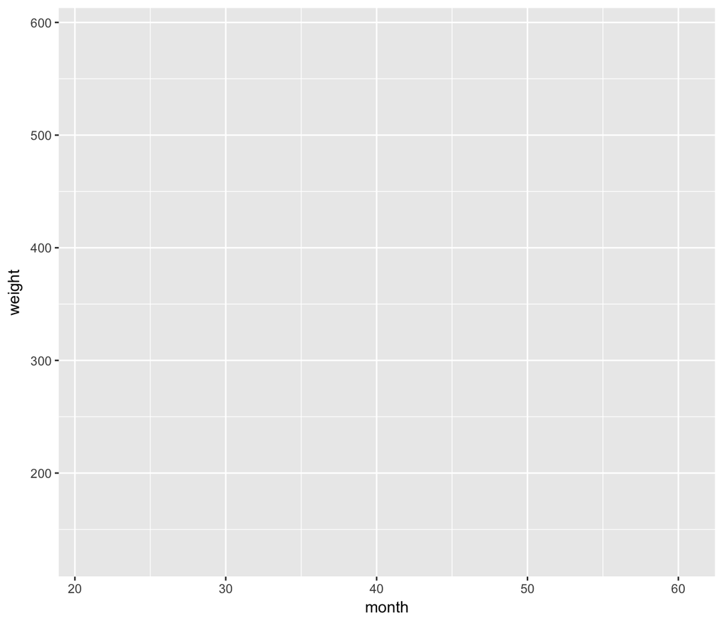

```r
g<-ggplot(df, aes(x=month,y=weight))

g
```

## 4.2. 산점도: + geom_point()

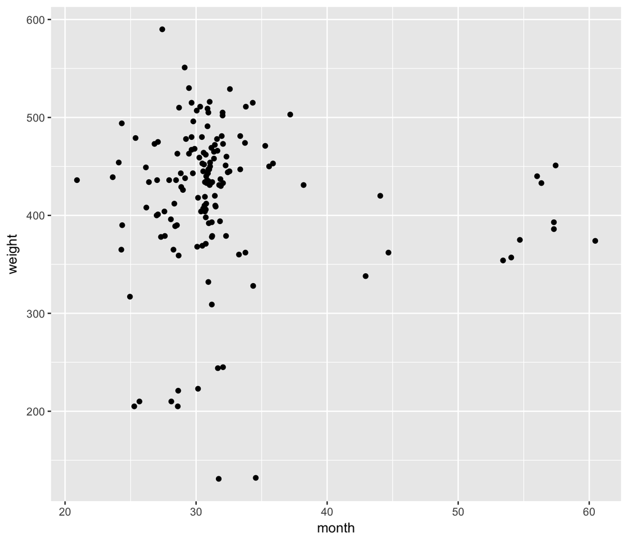

```r
g + geom_point()
```

## 4.3. 막대그래프: + geom_bar()

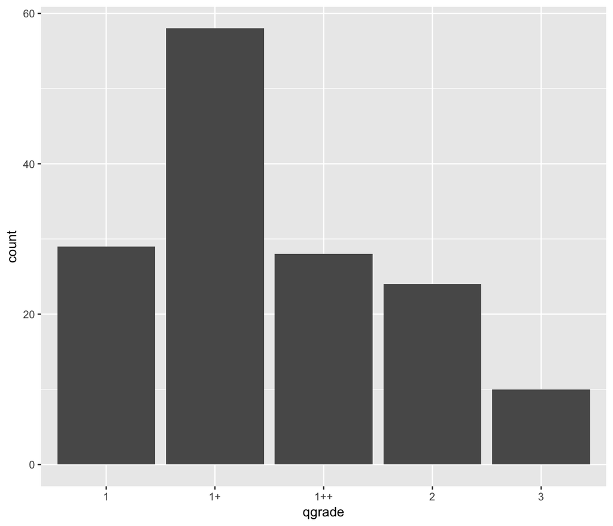

```r
h<-ggplot(df, aes(qgrade))

h + geom_bar()
```

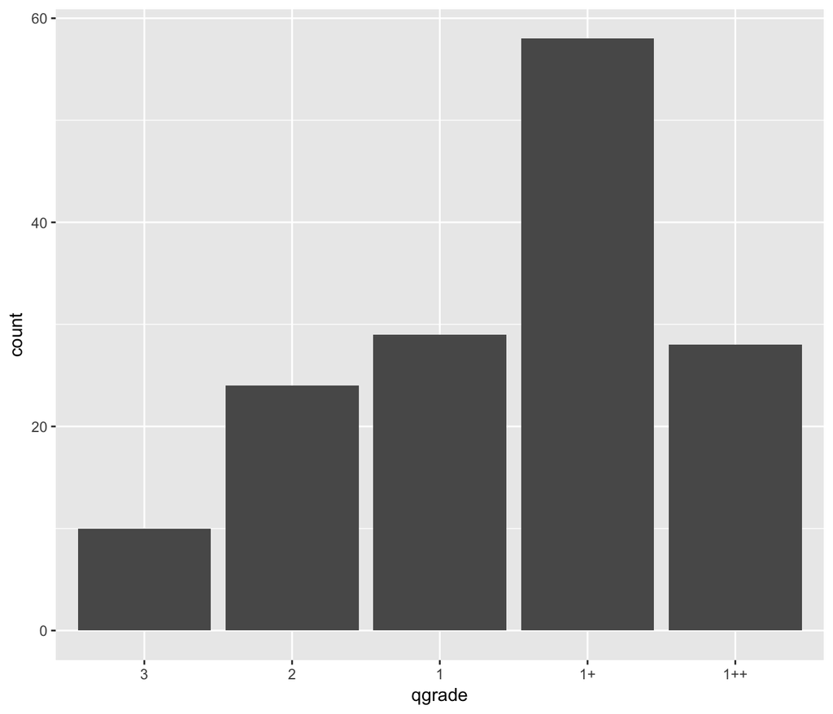

```r
h + geom_bar() + scale_x_discrete(limits=c("3","2","1","1+","1++")) #순서 지정하기
```

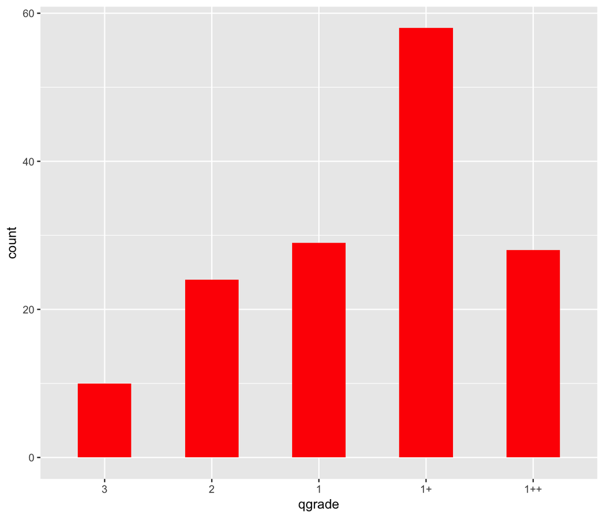

```r
h + geom_bar(width=0.5, fill="red") + scale_x_discrete(limits=c("3","2","1","1+","1++")) #너비 및 색 지정
```

## 4.4. 분포도 그리기: + geom_density()

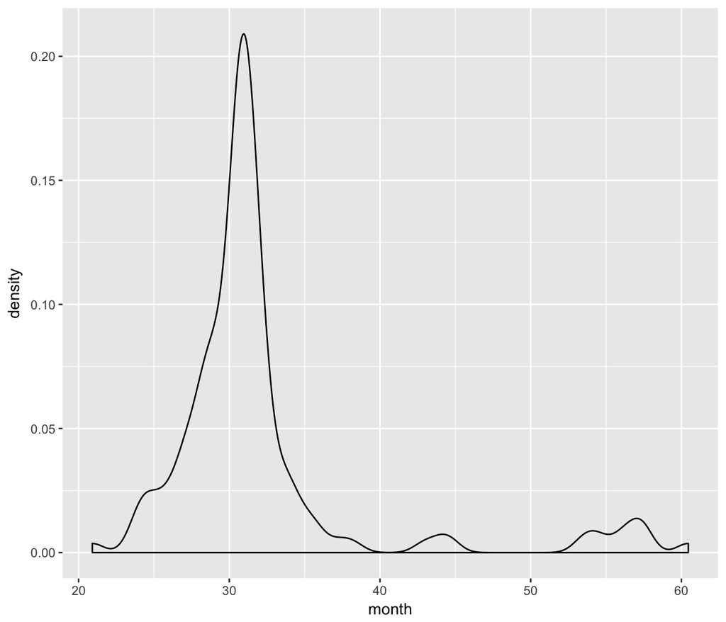

```r
g<-ggplot(df, aes(month))

g + geom_density(kernel="gaussian")
```

# 5. dplyr + ggplot

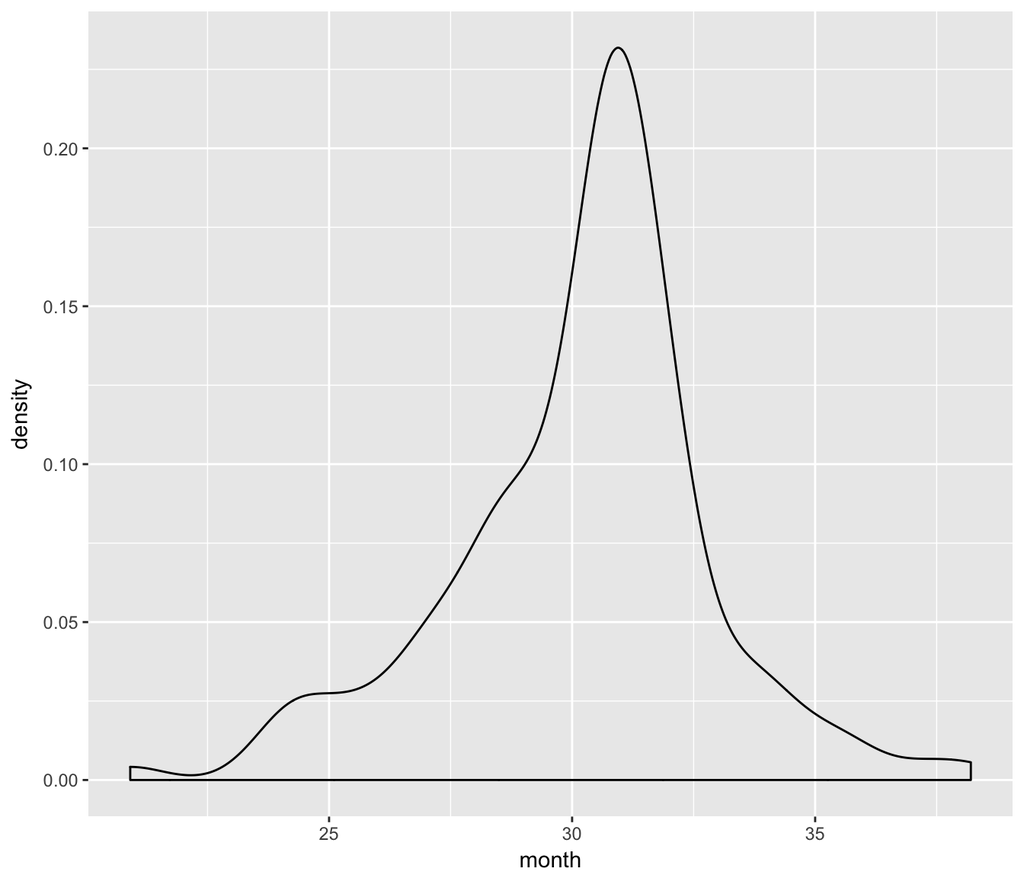

```r
filter(df, month<40) %>% ggplot(aes(month)) + geom_density(kernel="gaussian") #40개월 미만의 개체의 분포도
```

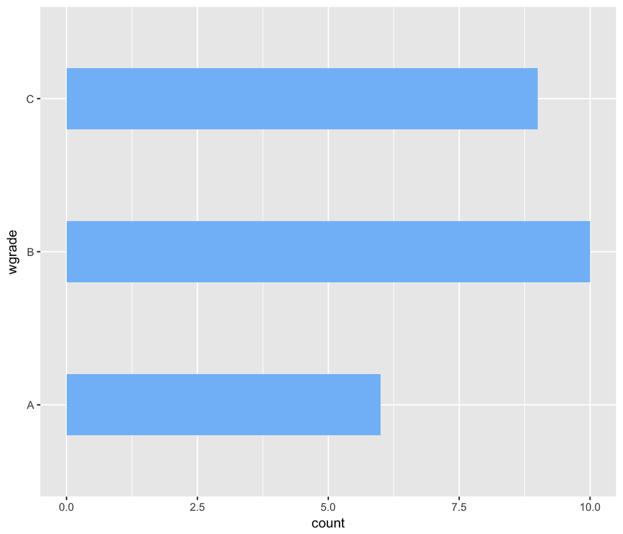

```r
filter(df, Name=="Kim") %>% ggplot(aes(wgrade)) + geom_bar(width=0.4, fill="#81BEF7") + coord_flip() #김씨네 육량등급
```

- html 컬러 차트: https://html-color-codes.info/Korean/

# 6. 연동형 문서 작성: R 마크다운

- **4. 연동형 문서 작성을 참고해 주세요**
- https://gist.github.com/ihoneymon/652be052a0727ad59601
- *워드나 한글로 예술 작품을 만들 필요는 없습니다 -> 보고서는 정보 전달이 목적*
- R 마크다운 = 기존의 마크다운 + R 코드를 재현
- 기본 데이터가 변하더라도 같은 형식의 보고서를 빠르게 작성할 수 있음

# 7. 결론

본 수업을 통해 기본적인 R 사용법을 배워보았습니다. 각자가 다뤄야 하는 데이터의 종류와 성격이 다르겠지만 기본적으로 데이터를 **가공하고-분석하고-해석하는** 일련의 과정들은 다르지 않을 것입니다. 지금은 비록 기본만 배웠지만 각자가 더 공부해 분석 및 보고서 작성과정에 들이는 시간을 줄일 수 있길 바래봅니다.